# ブートストラップ信頼区間(パーセンタイル法)

UPDATE: 2022-12-19 20:42:42

# はじめに

ブートストラップ信頼区間(パーセンタイル法)を書くことがあったので、その備忘録。今回の例では、ワイブル分布 (Weibull distribution) を例にする。この分布は、サバイバル分析などで出てくるように、人の死亡確率をモデリングする際に役立つ。人の死亡確率というと角が立ちそうだが、ECサイトの会員の離脱率なんかをイメージすると良いかもしれない。つまり、観測している期間において死亡確率は一定というよりも、死亡確率は時間と共に高くなり、変化するという仮定を起きたい時に便利。この反対もしかり。その事象が発生するまでの時間を確率変数と考えると、その確率変数が従う分布はワイブル分布となる。

## ブートストラップ

ブートストラップサンプリングとは、得られたサンプルデータから、リサンプリングを行うこと。そこから、リサンプルデータから統計量を求め、推測を行う方法のことをブートストラップ〇〇とか言う。ブートストラップ信頼区間(パーセンタイル法)ではリサンプリングされた値を使ってパーセンタイルを計算すると、その値が取りうる信頼区間が得られる。これを各値で計算していくことで得られる。

`{fitdistrplus}`パッケージを使っている。`{fitdistrplus}`パッケージの詳細は[こちら](https://cran.r-project.org/web/packages/fitdistrplus/fitdistrplus.pdf)。

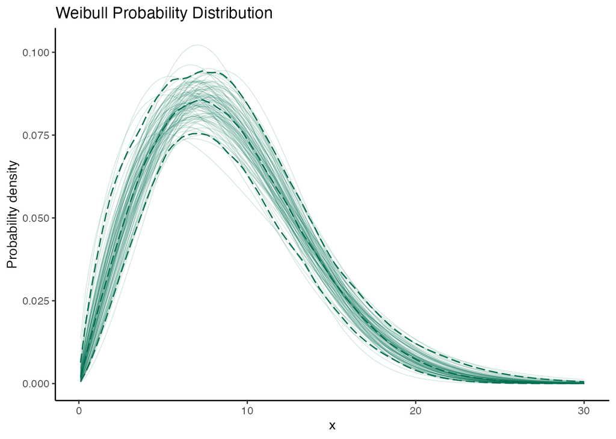

```r
library(fitdistrplus)
library(tidyverse)

set.seed(123)
n <- 100
df_prob <- rweibull(n = n, shape = 2, scale = 10)
x <- seq(0.1, 30, len = n)


loops <- 100
booted_df <- map_dfc(1:loops, function(i) {
  xi <- sample(df_prob, size = length(df_prob), replace = TRUE)
  MLE_est <- suppressWarnings(fitdist(xi, distr = "weibull",method = "mle"))
  dweibull(x, shape = MLE_est$estimate["shape"],  scale = MLE_est$estimate["scale"])
})

dat1 <- booted_df %>%
  bind_cols(x %>% as_tibble() %>% rename(x = value)) %>%
  gather(key = boot_ind, val = y, -x)

dat2 <- booted_df %>%
  array_tree(., 1) %>%
  map_dfc(., quantile, c(0.025, 0.5, 0.975)) %>%
  t() %>% as_tibble() %>%
  bind_cols(x %>% as_tibble()) %>%
  setNames(c("2.5%", "50%", "97.5%", "x")) %>%
  gather(key = quantile, val = y, -x)

ggplot() +
  geom_line(data = dat1, aes(x, y, group = boot_ind), col = "#006E4F", alpha = 0.2, size = 0.25) +
  geom_line(data = dat2, aes(x, y, group = quantile), col = "#006E4F", size = 0.5, linetype = "longdash") +
  theme_classic() + xlab("x") + ylab("Probability density") +
  ggtitle("Weibull Probability Distribution")
```